# Likelihoods

History of the course:

## 0.1 Outline

# 1 Likelihood Construction and Estimation

Why do Statisticians love likelihood-based estimation?

Downsides?

## 1.1 Introduction

**Definition:** Suppose random variables $\boldsymbol Y = (Y_1, \dots Y_n)^\top$ has joint density or probability mass function $f_\boldsymbol Y(\boldsymbol y, \boldsymbol \theta)$ where $\boldsymbol \theta = (\theta_1, \dots, \theta_b)$. Then the *likelihood function* is
$$L(\boldsymbol \theta | \boldsymbol Y) = f_\boldsymbol Y(\boldsymbol Y, \boldsymbol \theta).$$

**Key concept:** In all situations, the likelihood is the joint density of the observed data to be analyzed.

### 1.1.1 Notation

Given $\boldsymbol y$, note that $L(\boldsymbol \theta | \boldsymbol y): \mathbb{R}^b \rightarrow \mathbb{R}$.

Generally, we optimize $\ell(\boldsymbol \theta) = \log L(\boldsymbol \theta | \boldsymbol y)$.

How?

**Example:** Suppose we have $Y_1, \dots Y_n \stackrel{iid}{\sim} \text{Exp}(\lambda)$. The likelihood function is defined as

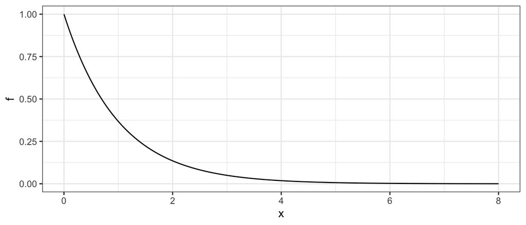

```r
# likelihood simulation
n <- 10
lambda <- 1

# plot of exponential(lambda) density
data.frame(x = seq(0, 8, .01)) |>
  mutate(f = dexp(x, rate = lambda)) |>
  ggplot() +
  geom_line(aes(x, f))
```

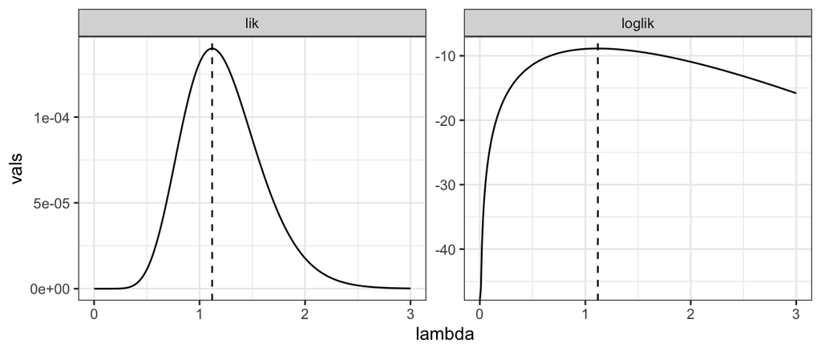

```r
# define likelihood
loglik <- function(lambda, data)
{
    lik <- prod(dexp(data, rate = lambda))
    loglik <- sum(dexp(data, rate = lambda, log = T))

    out <- data.frame(lik = lik, loglik = loglik)
    return(out)
}

# simulate data
data <- rexp(n = n, rate = lambda)

# plot likelihood and loglikelihood
data.frame(lambda = seq(0, 3, by = .01)) |>
  rowwise() |>
  mutate(loglik = loglik(lambda, data)) |>
  unnest(cols = c(loglik)) |>
  pivot_longer(-lambda, names_to = "func", values_to = "vals") |>
  ggplot() +
  geom_vline(aes(xintercept = 1 / mean(data)), lty = 2) + # max likelihood estimate is 1/mean
  geom_line(aes(lambda, vals)) +
  facet_wrap(~func, scales = "free")
```

The likelihood function is random!

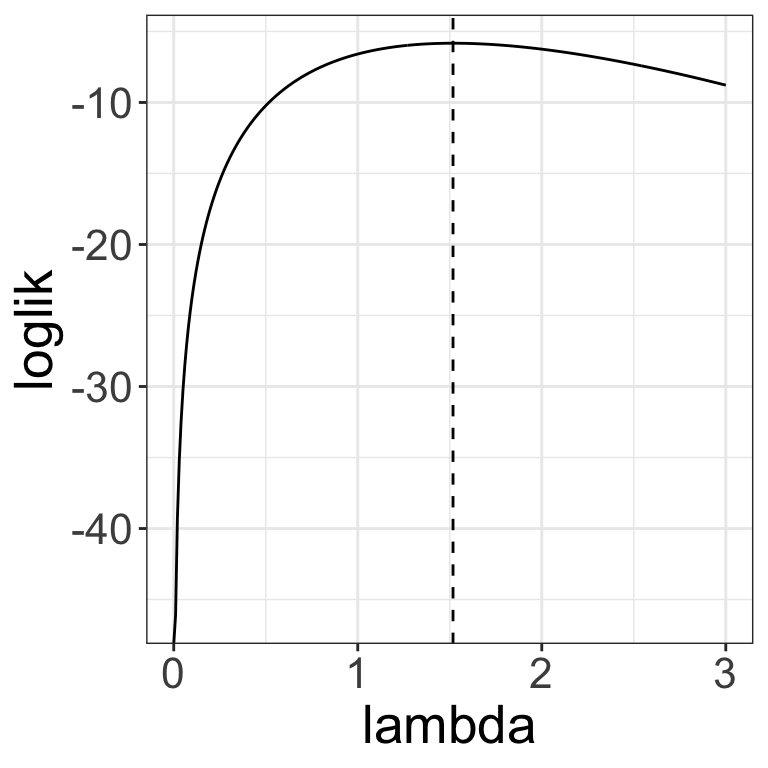

[figure not shown]

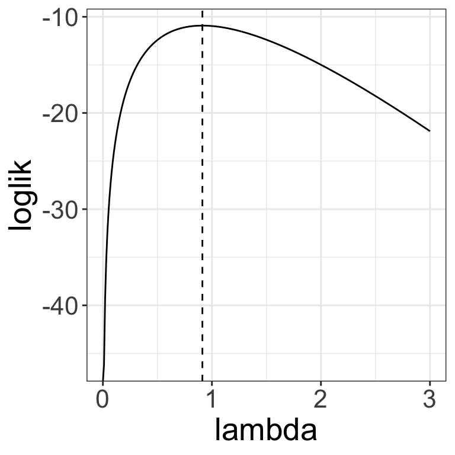

```r
for(i in seq_len(3)) {
  # simulate data
  data <- rexp(n = n, rate = lambda)

  # plot likelihood and loglikelihood
  data.frame(lambda = seq(0, 3, by = .01)) |>
    rowwise() |>
    mutate(loglik = loglik(lambda, data)) |>
    unnest(cols = c(loglik)) |>
    ggplot() +
    geom_vline(aes(xintercept = 1 / mean(data)), lty = 2) + # max likelihood estimate is 1/mean
    geom_line(aes(lambda, loglik)) +
    theme(text = element_text(size = 20)) -> p ## make legible in notes

    print(p)
}
```

**Your Turn:** What is the effect of sample size on the log-likelihood function? Make a plot showing the log-likelihood function that results from $n = 10$ vs. $n = 100$ with corresponding MLE.

## 1.2 Construction

The use of the likelihood function in parameter estimation is easiest to understand in the case of discrete iid random variables.

### 1.2.1 Discrete IID Random Variables

Suppose each of the $n$ random variables in the sample $Y_1, \dots, Y_n$ have probability mass function $f(y; \boldsymbol \theta) = P_\boldsymbol \theta(Y_1 = y), y = y_1, y_2, \dots$. The likelihood is then defined as:
$$L(\boldsymbol \theta | \boldsymbol Y) = \text{ joint density of observed random variables}$$

In other words,

**Example (Fetal Lamb Movements):** Data on counts of movements in five-second intervals of one fetal lamb ($n = 240$ intervals:)

| No. of Movements | 0 | 1 | 2 | 3 | 4 | 5 | 6 | 7 |
| --- | --- | --- | --- | --- | --- | --- | --- | --- |
| Count | 182 | 41 | 12 | 2 | 2 | 0 | 0 | 1 |

Assume a Poisson model: $P(Y = y) = f_Y(y; \lambda) = \frac{\exp(-\lambda)\lambda^y}{y!}$. Then the likelihood is

Equating the derivative of the loglikelihood with respect to $\lambda$ to zero and solving results in the MLE

$$\hat{\lambda}_\text{MLE} = \qquad\qquad\qquad\qquad\qquad\qquad\qquad\qquad\qquad\qquad\qquad\qquad\qquad\qquad$$

This is the best we can do with this model. But is it good?

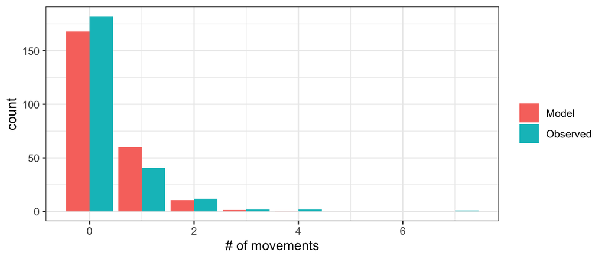

### 1.2.2 Multinomial Likelihoods

The multinomial distribution is a generalization of the binomial distribution where instead of 2 outcomes (success or failure), there are now $k \ge 2$ outcomes.

The probability mass function is

For $N_1, \dots, N_k, N_i =$ the number of balls in $i^\text{th}$ urn,

The maximum likelihood estimator of $p_i$:

More interesting multinomial likelihoods arise when the $p_i$ are modeled as a function of a lesser number of parameters $\theta_1, \dots, \theta_m$, $m < k - 1$.

**Example (Capture-Recapture):** To estimate fish survival during a specific length of time (e.g., one month), a common approach is to use a removal design.

### 1.2.3 Continuous IID Random Variables

Recall: the likelihood is the joint density of data to be analyzed.

**Example (Hurricane Data):** For $36$ hurricanes that had moved far inland on the East Coast of the US in 1900-1969, maximum 24-hour precipitation levels during the time they were over mountains.

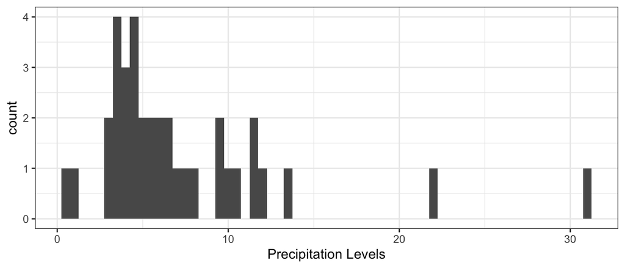

We model the precipitation levels with a gamma distribution, which has density
$$f(y; \alpha, \beta) = \frac{1}{\Gamma(\alpha) \beta^\alpha} y^{\alpha - 1}\exp(-y/\beta), \quad y > 0, \alpha, \beta > 0.$$
This leads to the likelihood

Of course, this cannot be interpreted as a probability because

To get a probability, need to go from a density to a measure.

But it may be useful to think of the value of the likelihood as being proportional to a probability.

More formally, begin with the definition of a derivative

$$g'(x) = \lim\limits_{h \rightarrow0^+} \frac{g(x + h) - g(x - h)}{2h}.$$

Let $F$ be the cumulative distribution function of a continuous random variable $Y$, then (if the derivative exists)

$$f(y) = \lim\limits_{h \rightarrow0^+} \frac{F(y + h) - F(y - h)}{2h} = \qquad \qquad \qquad \qquad \qquad$$

If we substitute this definition of a density into the definition of the likelihood

Compare this to the iid discrete case:

**Example (Hurricane Data, Cont’d):** Recall with a gamma model, the likelihood for this example is
$$L(\boldsymbol \theta | \boldsymbol Y) = \{\Gamma(\alpha)\}^{-n} \beta^{-n\alpha} \left\{\prod Y_i\right\}^{\alpha - 1} \exp\left(-\sum y_i/\beta\right),$$
and log-likelihood
$$\ell(\boldsymbol \theta) = \qquad \qquad \qquad \qquad \qquad \qquad \qquad \qquad$$

```r
## loglikelihood function
neg_gamma_loglik <- function(theta, data) {
  -sum(log(dgamma(data, theta[1], scale = theta[2])))
}

## maximize
mle <- nlm(neg_gamma_loglik, c(1.59, 4.458), data = hurr_rain)
mle$estimate
```

```
## [1] 2.187214 3.331862
```

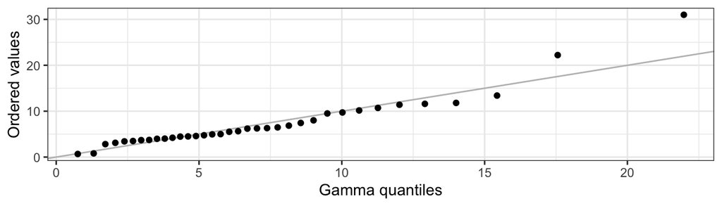

```r
## Gamma QQ plot
data.frame(theoretical = qgamma(ppoints(hurr_rain), mle$estimate[1], scale = mle$estimate[2]),
           actual = sort(hurr_rain)) |>
  ggplot() +
  geom_abline(aes(intercept = 0, slope = 1), colour = "grey") +
  geom_point(aes(theoretical, actual)) +
  xlab("Gamma quantiles") + ylab("Ordered values")
```

### 1.2.4 Mixtures of Discrete and Continuous RVs

Some data $Y$ often have a number of zeros and the amounts greater than zero are best modeled by a continuous distribution.

Ex:

In other words, they have positive probability of taking a value of exactly zero, but continuous distribution otherwise.

Another way to write this:

How to go from here to get a likelihood?

One approach: let $n_0$ be the number of zeroes in the data and $m = n - n_0$ be the number of non-zero $Y_i$. This leads to an intuitive way to construct the likelihood for iid $Y_1, \dots, Y_n$ distributed according to the above distribution:
$$L(\boldsymbol \theta | \boldsymbol Y) = \lim\limits_{h \rightarrow 0^+} \left(\frac{1}{2h}\right)^m \prod\limits_{i = 1}^n\{F_Y(Y_i + h; p, \boldsymbol \theta) - F_Y(Y_i - h; p, \boldsymbol \theta)\}$$

Feels a little arbitrary in how we are defining different weights on our likelihood for discrete and continuous parts.

Turns out, it doesn’t matter! (Need some STAT 630/720 to see why.)

**Definition (Absolute Continuity)** On $(\mathbb{X}, \mathcal{M})$, a finitely additive set function $\phi$ is *absolutely continuous* with respect to a measure $\mu$ if $\phi(A) = 0$ for each $A \in \mathcal{M}$ with $\mu(A) = 0$. We also say $\phi$ is *dominated* by $\mu$ and write $\phi \ll \mu$. If $\nu$ and $\mu$ are measures such that $\nu \ll \mu$ and $\mu \ll nu$ then $\mu$ and $\nu$ are *equivalent*.

**Theorem (Lebesgue-Randon-Nikodym)** Assume that $\phi$ is a $\sigma$-finite countably additive set function and $\mu$ is a $\sigma$-finite measure. There exist unique $\sigma$-finite countably additive set functions $\phi_s$ and $\phi_{ac}$ such that $\phi = \phi_{ac} + \phi_s, \phi_{ac} \ll \mu$, $\phi_s$ and $\mu$ are mutually singular and there exists a measurable extended real valued function $f$ such that
$$\phi_{ac}(A) = \int_A f d\mu, \qquad \text{ for all } A \in \mathcal{M}.$$
If $g$ is another such function, then $f = g$ a.e. wrt $\mu$. If $\phi \ll \mu$ then $\phi(A) = \int_Af d\mu$ for all $A \in \mathcal{M}$.

**Definition (Radon-Nikodym Derivative)** $\phi = \phi_{ac} + \phi_s$ is called the *Lebesgue decomposition*. If $\phi \ll \mu$, then the density function $f$ is called the *Radon-Nikodym derivative* of $\phi$ wrt $\mu$.

So what?

### 1.2.5 Proportional Likelihoods

Likelihoods are equivalent for point estimation as long as they are proportional and the constant of proportionality does not depend on unknown parameters.

Why?

Consider if $Y_i, i = 1, \dots, n$ are iid continuous with density $f_Y(y ; \boldsymbol \theta)$ and $X_i = g(Y_i)$ where $g$ is increasing and continuously differentiable. Because $g$ is one-to-one, we can construct $Y_i$ from $X_i$ and vice versa.

More formally, the density of $X_i$ is $f_X(x; \boldsymbol \theta) = f_Y(h(x); \boldsymbol \theta) h'(x)$, where $h = g^{-1}$, and
$$L(\boldsymbol \theta | \boldsymbol X) = \qquad \qquad \qquad \qquad \qquad \qquad \qquad \qquad$$

**Example (Likelihood Principle):** Consider data from two different sampling plans:

1. A binomial experiment with $n = 12$. Let $Y_i = 1$ if $i^{\text{th}}$ trial is a success and $0$ otherwise.
   $$L_1(p | \boldsymbol Y) = {12 \choose S} p^S (1 - p)^{12 - S}, \text{ where } S = \sum\limits_{i = 1}^n Y_i$$
2. A negative binomial experiment, i.e. run the experiment until three zeroes are obtained.
   $$L_2(p | \boldsymbol Y) = {S + 2 \choose S} p^S (1 - p)^3.$$
   The ratio of these likelihoods is
   $$\frac{L_1(p | \boldsymbol Y)}{L_2(p | \boldsymbol Y)} = \qquad \qquad\qquad\qquad\qquad\qquad\qquad\qquad\qquad\qquad\qquad\qquad\qquad$$

Suppose $S = 9$. Is all inference equivalent for these likelihoods? Debatable.

**The likelihood principle** states all the information about $\boldsymbol \theta$ from an experiment is contained in the actual observation $\boldsymbol y$. Two likelihood functions for $\boldsymbol \theta$ (from the same or different experiments) contain the same information about $\boldsymbol \theta$ if they are proportional.

### 1.2.6 Empirical Distribution Function as MLE

Recall the empirical cdf:

Suppose $y_{(1)} \le y_{(2)} \le \cdots \le y_{(n)}$ are the order statistics of an iid sample from an unknown distribution function $F_Y$. Our goal is to estimate $F_Y$.

$$\hat{F}_Y(y) = \frac{1}{n} \sum\limits_{i = 1}^n \mathbb{I}(y \ge y_{(i)})$$

Is this a “good” estimator of $F_Y$?

Yes, because it’s MLE.

Suppose $Y_1, \dots, Y_n$ are iid with distribution function $F(y)$. Here $F(y)$ is the unknown parameter.

An approximate likelihood for $F$ is

$$L_h(F | \boldsymbol Y) = \prod\limits_{i = 1}^n \{F(Y_i + h) - F(Y_i - h)\}$$

### 1.2.7 Censored Data

Censored data occur when the value is only partially known. This is different from *truncation*, in which the data does not include any values below (or above) a certain limit.

For example, we might sample only hourseholds that have an income above a limit, $L_0$. If all incomes have distribution $F(x; \boldsymbol \theta)$, then for $y > L_0$,

$$P(Y_1 \le y | Y_1 > L_0) = \qquad \qquad \qquad \qquad \qquad \qquad \qquad \qquad \qquad \qquad \qquad \qquad \qquad \qquad \qquad \qquad \qquad \qquad$$
The likelihood is then

#### 1.2.7.1 Type I Censoring

Suppose a random variable $X$ is normally distributed with mean $\mu$ and variance $\sigma^2$, but whenever $X \le 0$, all we observe is that it is less than or equal to $0$. If the sample is set to $0$ in the censored cases, then define
$$Y = \begin{cases}
0 & \text{ if } X \le 0 \\
X & \text{ if } X > 0.
\end{cases}$$
The distribution function of $Y$ is

Suppose we have a sample $Y_1, \dots, Y_n$ and let $n_0$ be the number of sample values that are $0$. Then $m = n - n_0$ and

We might have censoring on the left at $L_0$ and censoring on the right at $R_0$, but observe all values of $X$ between $L_0$ and $R_0$. Suppose $X$ has density $f(x; \boldsymbol \theta)$ and distribution function $F(x; \boldsymbol \theta)$ and
$$Y_i = \begin{cases}
L_0 & \text{ if } X_i \le L_0 \\
X_i & \text{ if } L_0 < X_i < R_0 \\
R_0 & \text{ if } X_i \ge R_0 \\
\end{cases}$$

If we let $n_L$ and $n_R$ be the number of $X_i$ values $\le L_0$ and $\ge R_0$ then the likelihood of the observed data $Y_1, \dots, Y_n$ is

We could also let each $X_i$ be subject to its own censoring values $L_i$ and $R_i$. For the special case of right censoring, define $Y_i = \min(X_i, R_i)$. In addition, define $\delta_i = \mathbb{I}(X_i \le R_i)$. Then the likelihood can be written as

**Example (Equipment failure times):** Pieces of equipment are regularly checked for failure (but started at different times). By a fixed date (when the study ended), three of the items had not failed and therefore were censored.

| y | 2 | 72 | 51 | 50 | 33 | 27 | 14 | 24 | 4 | 21 |
| --- | --- | --- | --- | --- | --- | --- | --- | --- | --- | --- |
| delta | 1 | 0 | 1 | 0 | 1 | 1 | 1 | 1 | 1 | 0 |

Suppose failure times follow an exponential distribution $F(x; \sigma) = 1 - \exp(-x/\sigma), x \ge 0$. Then
$$L(\sigma|\boldsymbol Y) = \qquad\qquad\qquad\qquad\qquad\qquad\qquad\qquad\qquad\qquad\qquad$$

#### 1.2.7.2 Random Censoring

So far we have considered censoring times to be fixed. This is not required.

This leads to random censoring times, e.g. $R_i$, where we assume that the censoring times are independent of $X_1, \dots, X_n$ and iid with distribution function $G(t)$ nd density $g(t)$.

Let’s consider the contributions to the likelihood:

which results in

$$L(\boldsymbol \theta | \boldsymbol Y, \boldsymbol \delta) = \qquad\qquad\qquad\qquad\qquad\qquad\qquad\qquad\qquad\qquad\qquad$$

## 1.3 Likelihoods for Regression Models

We will start with linear regression and then talk about more general models.

### 1.3.1 Linear Model

Consider the familiar linear model
$$Y_i = \boldsymbol x_i^\top \boldsymbol \beta + \epsilon_i, \qquad i =1, \dots, n,$$
where $\boldsymbol x_1, \dots, \boldsymbol x_n$ are known nonrandom vectors.

For likelihood-based estimation,

$$L(\boldsymbol \beta, \sigma | \{Y_i, \boldsymbol x_i\}_{i = 1}^n) = \qquad\qquad\qquad\qquad\qquad\qquad\qquad\qquad\qquad$$

What do you do when $\epsilon_i$ are not Gaussian?

**Example (Venice sea levels):** The annual maximum sea levels in Venice for 1931–1981 are :

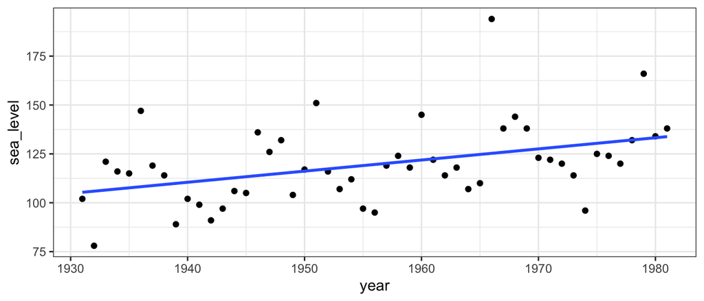

### 1.3.2 Additive Errors Nonlinear Model

### 1.3.3 Generalized Linear Models

Imagine an experiment where individual mosquitos are given some dosage of pesticide. The response is whether the mosquito lives or dies. The data might look something like:

**Goal:** Model the relationship between the predictor and response.

**Question:** What would a curve of best fit look like?

**Refined Goal:**

Let’s build a sensible model.

**Step 1:** Find a function that behaves the way we want.

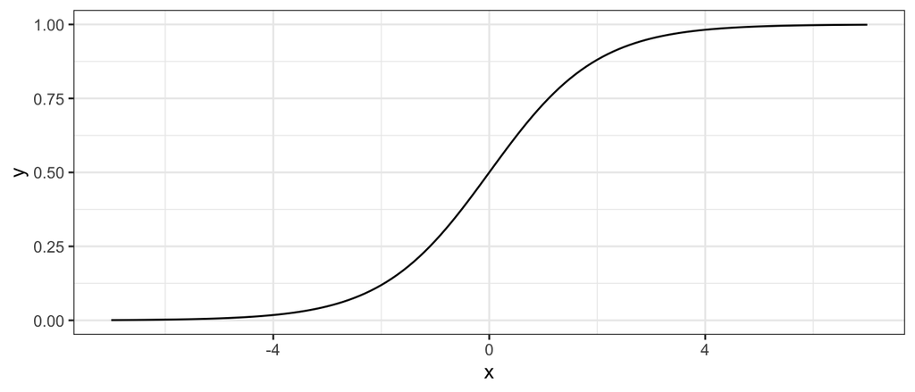

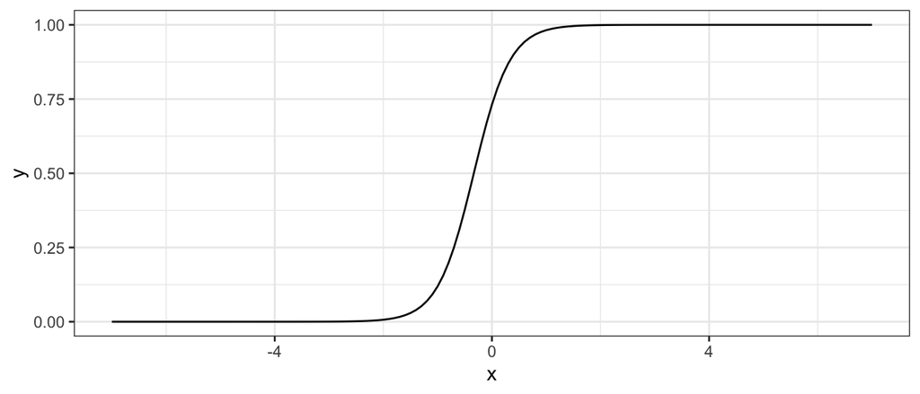

```r
# understanding the logistic function
# first, theta just equals x
x <- seq(-7, 7, .1)
theta <- x
y <- exp(theta)/(1 + exp(theta))
ggplot() + geom_line(aes(x, y))

# now, let theta be a linear function of x
theta <- 1 + 3*x
y <- exp(theta)/(1 + exp(theta))
ggplot() + geom_line(aes(x, y))
```

**Step 2:** Build a stochastic mechanism to relate to a binary response.

**Step 3:** Put Step 1 and Step 2 together.

Fitting our model: Does OLS make sense?

Consider the likelihood contribution.

$$L_i(p_i|Y_i) = \qquad\qquad\qquad\qquad\qquad\qquad\qquad\qquad\qquad\qquad\qquad\qquad\qquad$$
So the log-likelihood contribution is

$$\ell_i(p_i) = \qquad\qquad\qquad\qquad\qquad\qquad\qquad\qquad\qquad\qquad\qquad\qquad\qquad$$

Recall, we said $p_i = \frac{\exp(\theta_i)}{1 + \exp(\theta_i)}$ was sensible.

Which gives us,

$$\ell_i(\theta_i) = \qquad\qquad\qquad\qquad\qquad\qquad\qquad\qquad\qquad\qquad\qquad\qquad\qquad$$

So the log-likelihood is

$$\ell(\theta_1, \dots, \theta_n) = \qquad\qquad\qquad\qquad\qquad\qquad\qquad\qquad\qquad\qquad\qquad\qquad\qquad$$

To optimize?

```r
## data on credit default
data("Default", package = "ISLR")
head(Default)
```

```
##   default student   balance    income
## 1      No      No  729.5265 44361.625
## 2      No     Yes  817.1804 12106.135
## 3      No      No 1073.5492 31767.139
## 4      No      No  529.2506 35704.494
## 5      No      No  785.6559 38463.496
## 6      No     Yes  919.5885  7491.559
```

```r
## fit model with ML
m0 <- glm(default ~ balance, data = Default, family = binomial)
tidy(m0) |> kable()
```

| term | estimate | std.error | statistic | p.value |
| --- | --- | --- | --- | --- |
| (Intercept) | -10.6513306 | 0.3611574 | -29.49221 | 0 |
| balance | 0.0054989 | 0.0002204 | 24.95309 | 0 |

```r
glance(m0) |> kable()
```

| null.deviance | df.null | logLik | AIC | BIC | deviance | df.residual | nobs |
| --- | --- | --- | --- | --- | --- | --- | --- |
| 2920.65 | 9999 | -798.2258 | 1600.452 | 1614.872 | 1596.452 | 9998 | 10000 |

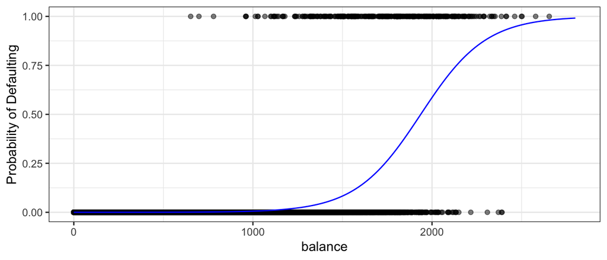

```r
## plot the curve
x_new <- seq(0, 2800, length.out = 200)
theta <- m0$coefficients[1] + m0$coefficients[2]*x_new
p_hat <- exp(theta)/(1 + exp(theta))

ggplot() +
  geom_point(aes(balance, as.numeric(default) - 1), alpha = 0.5, data = Default) +
  geom_line(aes(x_new, p_hat), colour = "blue") +
  ylab("Probability of Defaulting")
```

In general, a GLM is three pieces:

1. The random component
2. The systemic component
3. A linear predictor

Remarks:

**Example (Poisson regression):**

Consider a general family of distributions:

$$\log f(y_i; \theta_i, \phi) = \frac{y_i\theta_i - b(\theta_i)}{a_i(\phi)} + c(y_i, \phi).$$

**Example (Normal model):**

We can learn something about this distribution by considering it’s mean and variance. Because we don’t have an explicit form of the density, we rely on two facts:

1. $\text{E}\left[\frac{\partial \log f(Y_i; \theta_i, \phi)}{\partial \theta_i}\right] = 0.$
2. $\text{E}\left[\frac{\partial^2 \log f(Y_i; \theta_i, \phi)}{\partial \theta_i^2}\right] + \text{E}\left[\left(\frac{\partial \log f(Y_i; \theta_i, \phi)}{\partial \theta_i}\right)^2\right] = 0.$

For $\log f(y_i; \theta_i, \phi) = \frac{y_i\theta_i - b(\theta_i)}{a_i(\phi)} + c(y_i, \phi)$,

**Example (Bernoulli model):**
$$f(y_i; p_i) = p_i^{y_i}(1 - p_i)^{1 - y_i}$$

Finally, back to modelling. Our **goal** is to build a relationship between the mean of $Y_i$ and covariates $\boldsymbol x_i$.

**Example (Bernoulli model, cont’d):**

## 1.4 Marginal and Conditional Likelihoods

Consider a model which has $\boldsymbol \theta = (\boldsymbol \theta_1, \boldsymbol \theta_2)$, where $\boldsymbol \theta_1$ are the parameters of interest and $\boldsymbol \theta_2$ are nuisance parameters.

One way to improve estimation for $\boldsymbol \theta_1$ is to find a one-to-one transformation of the data $\boldsymbol Y$ to $(\boldsymbol V, \boldsymbol W)$ such that either

The key feature is that one component of each contains only the parameter of interest.

**Example (Neyman-Scott problem):** Let $Y_{ij}, i = 1, \dots, n, j = 1, 2$ be intependent normal random variables with possible different means $\mu_i$ but the same variance $\sigma^2$.

Our goal is to estimate $\sigma^2$. Should we be able to?

Following the usual arguments,

$$\hat{\mu}_{i, \text{MLE}} = \frac{Y_{i1} + Y_{i2}}{2} \qquad\qquad\qquad\qquad\qquad\qquad\qquad\qquad\qquad\\
\hat{\sigma}_{\text{MLE}}^2 = \frac{1}{2n}\sum\limits_{i = 1}^n \sum\limits_{j = 1}^2 (Y_{ij} - \hat{\mu}_{i, \text{MLE}})^2 \quad \qquad\qquad\qquad\qquad\qquad$$

$$\text{E}[\hat{\sigma}_{\text{MLE}}^2] = \qquad\qquad\qquad\qquad\qquad\qquad\qquad\qquad\qquad\qquad\qquad\qquad$$

A reworking of the data seems more promising. Let,
$$V_i = \frac{Y_{i1} - Y_{i2}}{\sqrt{2}} \qquad \text{and}\qquad W_i = \frac{Y_{i1} + Y_{i2}}{\sqrt{2}}$$

For conditional likelihoods, we can often exploit the existence of sufficient statistics for the nuisance parameters under the assumption that the parameter of interest is known.

**Example (Exponential Families):** The structure of exponential families is such that it is often possible to exploit their properties to eliminated nuisance parameters. Let $Y$ have a density of the form
$$f(y; \boldsymbol \eta) = h(y)\exp\left\{\sum\limits_{i = 1}^s \eta_i T_i(y) - A(\boldsymbol \eta)\right\},$$
then

Thus, exponential families often provide an automatic procedure for finding $\boldsymbol W$ and $\boldsymbol V$.

**Example (Logistic Regression):** For binary $Y_i$, the standard logistics regression model is
$$P(Y_i = 1) = p_i(\boldsymbol x_i, \boldsymbol \beta) = \frac{\exp(\boldsymbol x_i^\top\boldsymbol \beta)}{1 + \exp(\boldsymbol x_i^\top\boldsymbol \beta)}$$
and the likelihood is
$$L(\boldsymbol \beta | \boldsymbol Y, \boldsymbol X) = \qquad\qquad\qquad\qquad\qquad\qquad\qquad\qquad\qquad\qquad$$

## 1.5 The Maximum Likelihood Estimator and the Information Matrix

We have now talked about how to construct likelihoods in a variety of settings, now we can use those constructions to formalize how we make inferences about model parameters.

Recall the score function

$$S(\boldsymbol Y, \boldsymbol \theta) = \qquad\qquad\qquad\qquad\qquad\qquad\qquad\qquad\qquad\qquad$$

Generally, the maximum likelihood estimator $\hat{\boldsymbol \theta}_{\text{MLE}}$ is the value of $\boldsymbol \theta$ where the maximum (over the parameter space $\Theta$) of $L(\boldsymbol \theta | \boldsymbol Y)$ is attained.

Under the assumption that the log-likelihood is continuously differentiable, then

But not always (?!).

**Example (Exponential threshold model):** Suppose that $Y_1, \dots, Y_n$ are iid from the exponential distribution with a threshold parameter $\mu$,
$$f(y; \mu) = \begin{cases}
\exp\{-(y - \mu)\} & \mu < y < \infty \\
0 & \text{otherwise,}
\end{cases}$$
for $\infty < \mu < \infty$.

Consider the artificial data set $\boldsymbol y = [2.47, 2.35, 2.23, 3.53, 2.36]$.

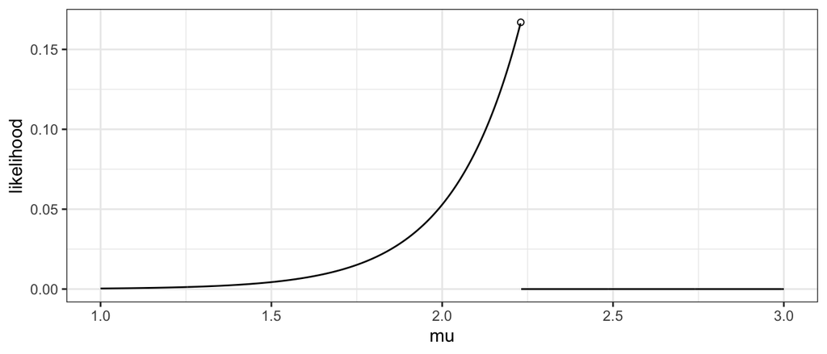

### 1.5.1 The Fisher Information Matrix

The Fisher information matrix $I(\boldsymbol \theta)$ is defined as the $b\times b$ matrix where
$$I_{ij}(\boldsymbol \theta) = \qquad\qquad\qquad\qquad\qquad\qquad\qquad\qquad\qquad$$

In matrix form,
$$I(\boldsymbol \theta) = \qquad\qquad\qquad\qquad\qquad\qquad\qquad\qquad\qquad$$

Fisher information facts:

1. The Fisher information matrix is the variance of the score contribution.
2. If regularity conditions are met,
   $$\sqrt{n}(\hat{\boldsymbol \theta}_{\text{MLE}} - \theta) \stackrel{d}{\rightarrow} \text{N}_{b}(0, I(\boldsymbol \theta)^{-1}).$$
3. If $b = 1$, then any unbiased estimator must have variance greater than or equal to $\{n I(\boldsymbol \theta)\}^{-1}$
4. The information matrix is related to the curvature of the log-likelihood contribution.

### 1.5.2 Observed Information

The information matrix is not random, but it is also not observable from the data.

Let $Y_1, \dots, Y_n$ be iid with density $f_Y(y_i; \boldsymbol \theta)$. The log likelihood is defined as

taking two derivatives and dividing by $n$ results in

**Definition:** The matrix $n\bar{I}(Y; \hat{\boldsymbol \theta}_{\text{MLE}})$ is called the sample information matrix, or the *observed information matrix*.

Why use $I(\boldsymbol \theta) = \text{E}\left[-\frac{\partial^2}{\partial \boldsymbol \theta\partial \boldsymbol \theta^\top} \log f(Y_1; \boldsymbol \theta)\right]$ as the basis for an estimator, rather than $I(\boldsymbol \theta) = \text{E}\left[\left\{\frac{\partial}{\partial \boldsymbol \theta^\top} \log f(Y_1; \boldsymbol \theta)\right\}\left\{\frac{\partial}{\partial \boldsymbol \theta} \log f(Y_1; \boldsymbol \theta)\right\}\right]$?

Now let’s prove the asymptotic normality of the MLE (in the scalar case).